# DATA606 Predicting Data Scientist Salary using Linear Regression

Jun Yan

November 30, 2017

## Introduction

In 2016, O’Reilly Media conducted a survey to find out what are the recent trends and salaries for data science professionals. The full report can be found here:

http://www.oreilly.com/data/free/files/2016-data-science-salary-survey.pdf

Particularly, the report created a regression model to predict a data scientist’s salary. Appendix B of the report listed the explainatory variables and weights for the variables. This model provides insights to the field, such as how do factors like age, country, education, past job title, tools used, etc. affect the data scientist’s wage.

In this project, I am interested in doing something similar - creating a linear regression model to estimate a data scientist’s salary. O’Reilly Media did not release their survey data. Fortunately, Kaggle has just recently published a data scientist survey done in 2017:

https://www.kaggle.com/kaggle/kaggle-survey-2017

The survey asked multitude of questions such gender, age, education level, nationality, past job title, etc. One of the questions was “What is your current total yearly compensation (salary + bonus)?” The answers to this question can be used as the response variable, while the answers to other questions can be treated as potential explanatory variables to be selected for the model.

This project uses following R packages:

```r
library(stringr)
library(dplyr)
library(knitr)
library(kableExtra)
library(car)
```

## Initial Data Exploration

The Kaggle survey data packages include 5 files. Kaggle provided the following descriptions for these files.

- `schema.csv`: a CSV file with survey schema. This schema includes the questions that correspond to each column name in both the `multipleChoiceResponses.csv` and `freeformResponses.csv`.
- `multipleChoiceResponses.csv`: Respondents’ answers to multiple choice and ranking questions. These are non-randomized and thus a single row does correspond to all of a single user’s answers.
- `freeformResponses.csv`: Respondents’ freeform answers to Kaggle’s survey questions. These responses are randomized within a column, so that reading across a single row does not give a single user’s answers.
- `conversionRates.csv`: Currency conversion rates (to USD) as accessed from the R package “quantmod” on September 14, 2017
- `RespondentTypeREADME.txt`: This is a schema for decoding the responses in the “Asked” column of the schema.csv file.

In this project, we use the `multipleChoiceResponses.csv` for the regression model.

Importantly, not every question was shown to every respondent. Below is a note from Kaggle:

“In an attempt to ask relevant questions to each respondent, we generally asked work related questions to employed data scientists and learning related questions to students. There is a column in the `schema.csv` file called ‘Asked’ that describes who saw each question.”

Thus there are questions not shown to all surveyees, based on the surveyee’s employment status, and the `schema.csv` file can be used to identify these survey questions. The first step of the project will be to filter out these questions, since including these questions (variables) may introduce bias to the model. We will only focus on questions shown to all surveyees. Lastly, the `conversionRates.csv` is helpful to convert the compensation values to US dollars, since the surveyees answered this question based on their countries’ currencies.

Let us import the relevant data.

```r
ds <- read.csv("kaggle-survey-2017/multipleChoiceResponses.csv", stringsAsFactors = F)
cr <- read.csv("kaggle-survey-2017/conversionRates.csv", stringsAsFactors = F)
sch <- read.csv("kaggle-survey-2017/schema.csv", stringsAsFactors = F)
```

Let’s check the dimension of each data.

```r
dim_ds <- dim(ds)
dim_cr <- dim(cr)
dim_sch <- dim(sch)
dimension <- data.frame(dim_ds, dim_cr, dim_sch, row.names = c("Rows", "Columns"))
kable(dimension, "html") %>%
  kable_styling(bootstrap_options = "striped", full_width = F)
```

|  | dim_ds | dim_cr | dim_sch |
| --- | --- | --- | --- |
| Rows | 16716 | 86 | 290 |
| Columns | 228 | 3 | 3 |

## Data Cleaning and Preparation

### Removing Blank Cells

There are NA and blank cells (“”) within the `ds` data:

```r
# Check NA cells
paste("Found", table(is.na(ds))[2], "NA cells in the data.")
```

```
## [1] "Found 77129 NA cells in the data."
```

```r
# Check blank cells
paste("Found", table(ds=="")[2], "blank cells in the data.")
```

```
## [1] "Found 2797109 blank cells in the data."
```

We would like to turn all blank cells into NA.

```r
# Transform blank cells into NA cells
is.na(ds) <- ds == ""
```

### Converting Salary Data

The `CompensationCurrency` column in the `ds` table identifies what currency the salary value is based on. The `CompensationAmount` column contains the salary value entered by the surveyees. These values are still in string form. Below step converts them into numeric values.

```r
ds$CompensationAmount <- ds$CompensationAmount %>%
  str_replace_all(",","") %>%
  as.numeric()
```

Next, we are going to join the `multipleChoiceResponses` ds table and the `conversionRate` cr table together, using the `CompensationCurrency` as key. At the same time, the `CompensationAmount` can be converted to US dollars using the `exchangeRate` column of the cr table, and stored as a new column named `Salary`. This will be our response variable, in which the linear regression model is trained to predict.

```r
cr <- rename(cr, CompensationCurrency = originCountry)
ds <- ds %>%
  left_join(cr, by = "CompensationCurrency") %>%
  mutate(Salary = CompensationAmount*exchangeRate) %>%
  mutate(Salary = round(Salary))
```

In the following step, we remove any data where the `Salary` column is NA. These are the cases where the surveyees did not respond to the `CompensationAmount` or `CompensationCurrency` questions, or the `CompensationCurrency` entered was not in the `exchangeRate` column.

```r
ds <- filter(ds, !is.na(ds$Salary))
```

Next we are going to remove few columns in the ds table. Since we have completed the currency conversion to create the `Salary` column, we can remove the `CompensationAmount` and `CompensationCurrency` columns. During the model selection process, the model may pick up these two variables since they are highly correlated to the `Salary` variable. Likewise, the `exchangeRate` column is removed.

```r
remove_col <- which(names(ds) %in% c(names(cr), "CompensationAmount"))
ds <- ds[,-remove_col]
```

Let’s see how many cases we have left.

```r
dim(ds)
```

```
## [1] 4373  227
```

Thus we have 4373 rows left after the cleaning. The data is now ready for regression model training.

### Potential Explanatory Variables

The main objective of this step is to create a reference table named `exp_vars`, which contains all of the potential explanatory variables. The `exp_vars` is to have 4 columns:

- `Column` contains the names of the survey questions. Example: “Country”.
- `Question` contains the the survey questions. Example: “Select the country you currently live in.”
- `Num.levels` contains the numbers of levels for each question. Example: “52” (there are 52 unique countries in the dataset)
- `Levels` contains the levels for each question. Example: “Argentina, Australia, Belarus, Belgium, Brazil, Canada…”.

This table will be very helpful in the variable selection step.

First we would like to identify the survey questions (columns) not shown to all surveyees. These will be excluded from the `exp_vars` table. The `Column` column of the `sch` table (schema) contains all the questions in the survey, and the `Asked` column identify whether the question is shown to all surveyees, or only shown to a subset of the surveyees.

```r
all_shown <- c()
i <- 0
for (question in names(ds)){
  if (question %in% sch$Column){
    row <- which(sch$Column == question)
    if (sch[row, "Asked"] == "All"){
      i <- i + 1
      all_shown[i] <- question
    }

  }
}
length(all_shown)
```

```
## [1] 43
```

Here, a vector named `all_shown` is created to extract the mutiple choice survey questions that are shown to all surveyees. The code found 43 such questions.

Two helper functions are created.

```r
# This function takes the name of the survey question and the scheme data, and return the row of the question
# question = a string vector containing the question names from the sch$Column
findRow <- function(question){
  row <- which(sch$Column == question)
  return(sch[row,])
}

# This function takes the name of the survey question and the survey data, and returns the levels of answer to the question.
# question = a string vector containing the question names
findLvl <- function(question){
  vec <- which(names(ds)==question)
  vec <- ds[,vec]
  temp <- levels(as.factor(vec))
  return(temp)
}
```

We can now construct the `exp_vars` table.

```r
# Use findRow function to extract information from the schema table for only those questions shown to all surveyee.
exp_vars <- all_shown %>%
  sapply(findRow) %>%
  t() %>%
  data.frame(row.names=NULL)
# Apply findLvl function to extract from the survey data the levels of answer to each question.
all_levels <- sapply(all_shown, findLvl)
# Create a new column, counting the number of levels for each question.
exp_vars$Num.Levels <- sapply(all_levels, length)
# Create a new column, collecting all levels for the question.
exp_vars$Levels <- sapply(all_levels, paste, collapse="~")
# Remove the "Asked" redundant column.
exp_vars <- exp_vars[,-which(names(exp_vars)=="Asked")]
head(sort(exp_vars$Num.Levels, decreasing = T))
```

```
## [1] 2857 1026 1006  669  570  100
```

```r
kable(exp_vars[1:5,1:3])
```

| Column | Question | Num.Levels |
| --- | --- | --- |
| GenderSelect | Select your gender identity. - Selected Choice | 4 |
| Country | Select the country you currently live in. | 52 |
| Age | What’s your age? | 64 |
| EmploymentStatus | What’s your current employment status? | 3 |
| MLToolNextYearSelect | Which tool or technology are you most excited about learning in the next year? (Select one option) - Selected Choice | 51 |

### Create New Explanatory variables

There is still yet a problem. Some of the questions were answered using check boxes, in which the surveyee can check off mutiple boxes. In each case, the survey data table concatenated the boxes that the surveyee checked off for that question.

For example, the question “MLTechniquesSelect” has a checkbox type answer, contains 1026 levels of answer.

```r
exp_vars[which(exp_vars$Column=="MLTechniquesSelect"),"Num.Levels"]
```

```
## [1] 1026
```

In reality, these levels are just unique combination of the boxes check off by the surveyees. We will need to find the “base levels” for these type of questions.

Following helper function can perform this task:

```r
# This function takes a question that has check-box type answers and return the avaiable box selections
# question = a string vector containing the question names from the exp_vars$Column
findSelections <- function(question){
  temp <- which(exp_vars$Column == question) %>%
    exp_vars[.,"Levels"] %>%
    str_split("~") %>%
    unlist() %>%
    str_split(",") %>%
    unlist() %>%
    unique()
  return(temp)
}
```

Testing this on the “MLTechniquesSelect” question returns the base levels (boxes) for this question.

```r
findSelections("MLTechniquesSelect")
```

```
##  [1] "Bayesian Techniques"
##  [2] "Decision Trees - Gradient Boosted Machines"
##  [3] "Decision Trees - Random Forests"
##  [4] "Ensemble Methods"
##  [5] "Evolutionary Approaches"
##  [6] "Gradient Boosting"
##  [7] "Hidden Markov Models HMMs"
##  [8] "Logistic Regression"
##  [9] "Markov Logic Networks"
## [10] "Neural Networks - CNNs"
## [11] "Neural Networks - GANs"
## [12] "Neural Networks - RNNs"
## [13] "Support Vector Machines (SVMs)"
## [14] "Other (please specify; separate by semi-colon)"
```

Further, these checkbox-type questions have to be broken down into separate, binary variables containing two levels: True or False. If the surveyee checked the boxes, the value will be True. For example, we will create a new variable “MLTechniquesSelect_BayesianTechnique”. If the surveyee did not check off the box, the value for this new variable will be False. Otherwise, it is True.

```r
# This function takes a question that has check-box type answer and use
# the available box selections to create features (columns), in which each
# column contains boolean value indicating if the surveyee checked the box.
# The function returns a data.frame object.
# question = a string vector containing the question names
createFeatures <- function(question){
  base_lvls <- findSelections(question)
  col <- which(names(ds)==question)
  vec <- ds[,col]
  temp <- lapply(vec, str_detect, base_lvls)
  temp <- data.frame(matrix(unlist(temp), nrow=length(temp), byrow=T))
  names(temp) <- base_lvls %>%
    str_replace_all("[[:punct:]]| ", "") %>%
    paste(question, ., sep="_")
  return(temp)
}
```

The above helper function will create a data.frame object, where the columns are the newly created variables, and each row indicate if each survey checked off the boxes or not.

Testing this on the “MLTechniquesSelect” question:

```r
temp <- createFeatures("MLTechniquesSelect")
kable(temp[1:5, 1:2])
```

| MLTechniquesSelect_BayesianTechniques | MLTechniquesSelect_DecisionTreesGradientBoostedMachines |
| --- | --- |
| TRUE | TRUE |
| NA | NA |
| FALSE | TRUE |
| TRUE | TRUE |
| FALSE | TRUE |

We will now identify the check-box type survey questions, create the new columns, and use cbind to include them in the `ds` table

```r
checkbox_questions <- c("LearningPlatformSelect", "MLTechniquesSelect",
                        "PastJobTitlesSelect", "BlogsPodcastsNewslettersSelect",
                        "MLSkillsSelect", "PublicDatasetsSelect")
new_columns <- lapply(checkbox_questions, createFeatures)
ds <- cbind(ds, new_columns)
```

We also want to update the `exp_vars` table to include these new variables.

```r
# Create pattern to be used as parameter for the str_extract function
pattern <- checkbox_questions %>%
  paste("_[[:print:]]*", sep="") %>%
  paste(collapse="|")
# Use str_extract to detect and extract the names of new columns in ds
new_features <- unlist(str_extract_all(names(ds), pattern))
# This function finds the full question given the name of the survey question of the new features
# question = a string vector containing the question names
findQsn <- function(question){
  strings <- str_extract(question, "\\w*_")
  strings <- str_replace(strings, "_", "")
  temp <- findRow(strings)
  return(temp$Question)
}
# Construct the data frame
new_features <- data.frame(Column = new_features,
                           Question = sapply(new_features, findQsn),
                           Num.Levels = rep(2, length(new_features)),
                           Levels = rep("TRUE|FALSE", length(new_features)))
# Combine with the exp_vars
exp_vars <- rbind(exp_vars, new_features)
```

There are two variables that we will need to remove from the `exp_vars` table - LearningCategory, and LearningPlatformUsefulness.

```r
# Identify the questions related to "LearningCategory" and "LearningPlatformUsefulness"
lcpu_questions <- exp_vars$Column %>%
  sapply(str_extract, "LearningCategory\\w*|LearningPlatformUsefulness\\w*") %>%
  .[!is.na(.)]
remove_features <- c(checkbox_questions, lcpu_questions,
                     "MLToolNextYearSelect", "MLMethodNextYearSelect")
exp_vars <- exp_vars[!(exp_vars$Column %in% remove_features),]
row.names(exp_vars) <- c(1:length(exp_vars$Column))
```

We are ready to move to the next step. But before that, take a look at the `exp_var` table.

```r
kable(exp_vars[1:10,1:3])
```

| Column | Question | Num.Levels |
| --- | --- | --- |
| GenderSelect | Select your gender identity. - Selected Choice | 4 |
| Country | Select the country you currently live in. | 52 |
| Age | What’s your age? | 64 |
| EmploymentStatus | What’s your current employment status? | 3 |
| LanguageRecommendationSelect | What programming language would you recommend a new data scientist learn first? (Select one option) - Selected Choice | 12 |
| DataScienceIdentitySelect | Do you currently consider yourself a data scientist? - Selected Choice | 3 |
| FormalEducation | Which level of formal education have you attained? | 7 |
| MajorSelect | Which best describes your undergraduate major? - Selected Choice | 15 |
| Tenure | How long have you been writing code to analyze data? | 6 |
| FirstTrainingSelect | How did you first start your machine learning / data science training? (Select one option) - Selected Choice | 6 |

```r
dim(exp_vars)[1]
```

```
## [1] 103
```

Therefore, we have 103 potential explanatory variables, which we will be selecting from in our regression model. Below is a list of these variables:

```r
unlist(exp_vars$Column)
```

```
##                                                                        GenderSelect
##                                                                      "GenderSelect"
##                                                                             Country
##                                                                           "Country"
##                                                                                 Age
##                                                                               "Age"
##                                                                    EmploymentStatus
##                                                                  "EmploymentStatus"
##                                                        LanguageRecommendationSelect
##                                                      "LanguageRecommendationSelect"
##                                                           DataScienceIdentitySelect
##                                                         "DataScienceIdentitySelect"
##                                                                     FormalEducation
##                                                                   "FormalEducation"
##                                                                         MajorSelect
##                                                                       "MajorSelect"
##                                                                              Tenure
##                                                                            "Tenure"
##                                                                 FirstTrainingSelect
##                                                               "FirstTrainingSelect"
##                                                                    ParentsEducation
##                                                                  "ParentsEducation"
##
##                                                      "LearningPlatformSelect_Arxiv"
##
##                                                      "LearningPlatformSelect_Blogs"
##
##                                          "LearningPlatformSelect_CollegeUniversity"
##
##                                   "LearningPlatformSelect_Companyinternalcommunity"
##
##                                                "LearningPlatformSelect_Conferences"
##
##                                             "LearningPlatformSelect_Friendsnetwork"
##
##                                                     "LearningPlatformSelect_Kaggle"
##
##                                                "LearningPlatformSelect_Newsletters"
##
##                                 "LearningPlatformSelect_NonKaggleonlinecommunities"
```

[output cut: 151 more lines]

```
##                              "MLSkillsSelect_Otherpleasespecifyseparatebysemicolon"
##
## "PublicDatasetsSelect_DatasetaggregatorplatformieSocrataKaggleDatasetsdataworldetc"
##
##                                                       "PublicDatasetsSelect_GitHub"
##
##                                                 "PublicDatasetsSelect_GoogleSearch"
##
##                                            "PublicDatasetsSelect_Governmentwebsite"
##
##                               "PublicDatasetsSelect_Icollectmyowndataegwebscraping"
##
##                     "PublicDatasetsSelect_UniversityNonprofitresearchgroupwebsites"
##
##                                                        "PublicDatasetsSelect_Other"
```

## Linear Regression

### Response Variable Transformation

Let’s inspect the distribution of `Salary` column, our response variable.

```r
summary(ds$Salary)
```

```
##       Min.    1st Qu.     Median       Mean    3rd Qu.       Max.
## -7.400e+01  2.052e+04  5.381e+04  6.591e+06  9.567e+04  2.830e+10
```

The distribution range is very wide, and there are some outliers that apparently do not make sense. For example, the maximum salary here is 28 billions USD, and the minimum salary is shown to be -74 dollars, a loss. We will need to remove these obviously erroneous cases.

If the IQR*1.5 criteria is used to remove the outliers, we may be removing too much data. Here, we opt to take out 1% of data from the top and bottom respectively.

```r
one_percent <- round(0.01 * dim(ds)[1])
bottom <- max(sort(ds$Salary)[1:one_percent])
top <- min(sort(ds$Salary, decreasing = T)[1:one_percent])
ds <- filter(ds, Salary > bottom & Salary < top)
summary(ds$Salary)
```

```
##    Min. 1st Qu.  Median    Mean 3rd Qu.    Max.
##       1   21525   53812   64637   95470  299000
```

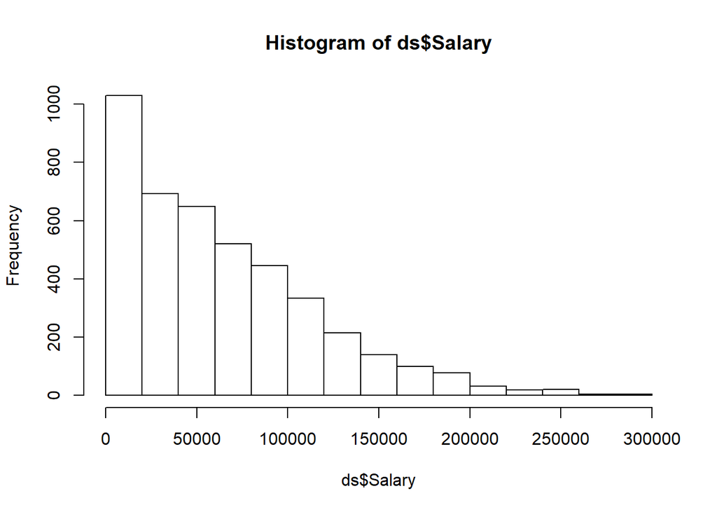

```r
hist(ds$Salary)
```

The regression model trained using response variable skewed like this may violate the constant variance of error assumption. The response variable has to be transformed to be more normal.

Here, we opt to use the Box Cox Transformation. This transformation uses the following formula:

$y=\frac { { x }^{ \lambda }-1 }{ \lambda }$

Here, x is the variables we wish to transform, and y is the resulting transformed variables. $\lambda$ is a controlling parameter and is usually 0.4.

Blow, two functions are created to transform a variale using Box Cox Tranformation, and to convert a transformed variable back to its original form.

```r
# Perform BoxCoxTransformation
bct <- function(vec, lambda = 0.4) return((vec^lambda-1)/lambda)

# Perform inverse of BoxCoxTransformation
invbct <- function(vec, lambda = 0.4) return((vec*lambda+1)^(1/lambda))
```

The `Salary` variable can now be transformed.

```r
ds$Salary <- bct(ds$Salary)
summary(ds$Salary)
```

```
##    Min. 1st Qu.  Median    Mean 3rd Qu.    Max.
##     0.0   132.7   192.6   185.7   242.9   384.9
```

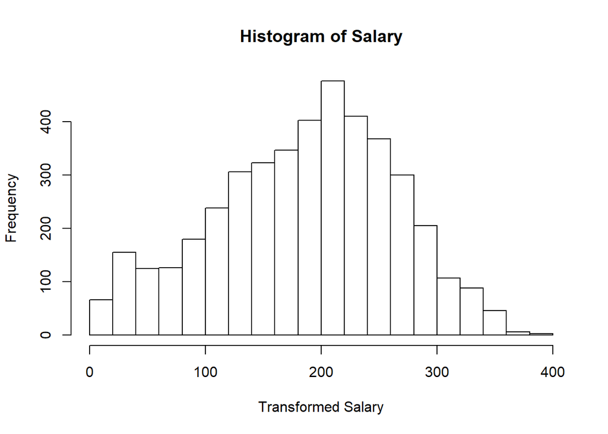

```r
hist(ds$Salary, main = "Histogram of Salary", xlab = "Transformed Salary")
```

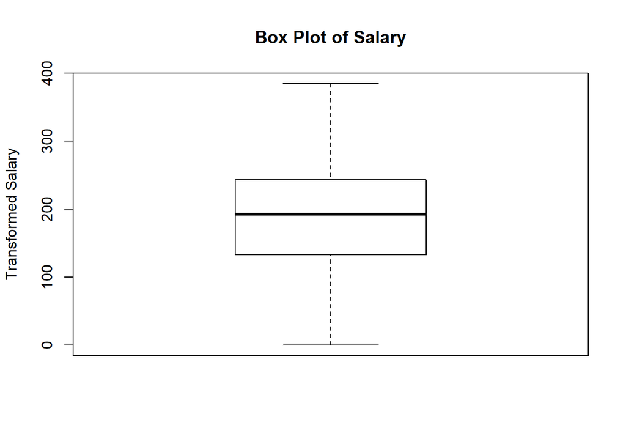

```r
boxplot(ds$Salary, main = "Box Plot of Salary", ylab ="Transformed Salary")
```

As you can see, it a lot more normally distributed.

### Helper Functions

Three helper functions are created to wrap the common tasks together.

```r
# This functions returns the adjusted R square for the linear model
# question = a string vector or list containing the question names
calAdjRsqr <- function(question){
  formula <- question %>%
    paste(collapse="+") %>%
    paste("Salary", "~", .) %>%
    as.formula()
  ds$Salary[is.infinite(ds$Salary)] <- NA
  fit <- lm(formula, data = ds)
  return(summary(fit)$adj.r.squared)
}
```

The above function, `calAdjRsqr`, calculates the adjusted R square given the names of the survey questions (variables). For example, the adjusted R square for the model using “Age” and “GenderSelect” as explainatory variables will yield following adjusted R square:

```r
calAdjRsqr(c("Age", "GenderSelect"))
```

```
## [1] 0.148365
```

Note that we wrap the `lm` function inside the `calAdjRsqr` to perform the linear regression.

Next, we created two recursive functions to calculate the adjusted R squares for two cases - when we eliminate a variable from the existing collection of explanatory variables, or when we add a variable to the collection.

```r
# This functions calculates the adj R squares of the models resulted from taking out each variable
# explain = a string vector or list containing the question names referencing the explainatory variables in the model
# pos = starting position of the search in the explain vector
backwardSearch <- function(explain, pos = 1){
  if (pos > length(explain)) return(c())
  temp <- c(calAdjRsqr(explain[-pos]), backwardSearch(explain, pos+1))
  return(temp)
}
# This functions calculates the adj R squares of the models resulted from adding a variable
# explain = a string vector or list containing the question names referencing the explainatory variables in the model
# add_explain = a string vector or list containing the explainatory variables to be added to the model
# pos = starting position of the search in the add_explain vector
forwardSearch <- function(explain, add_explain, pos=1){
  if (pos > length(add_explain)) return(c())
  temp <- c(calAdjRsqr(c(explain, add_explain[pos])), forwardSearch(explain, add_explain, pos+1))
  return(temp)
}
```

Given a vector list of variables (in the form of survey question names), the `backwardSearch` function will call upon `calAdjRsqr` as well as itself to calculate the adjusted R square if each of the variable is taken out of the model. As a concrete example, below is a test when the function is run to see what happen to the adjust R square when each of the variable in the model using explainatory variables “Age”, “GenderSelect”, and “Country”, is taken out of the model.

```r
# When "Age" is taken out of the model
calAdjRsqr(c("GenderSelect", "Country"))
```

```
## [1] 0.4928699
```

```r
# When "GenderSelect" is taken out of the model
calAdjRsqr(c("Age", "Country"))
```

```
## [1] 0.5382351
```

```r
# When "Country" is taken out of the model
calAdjRsqr(c("Age", "GenderSelect"))
```

```
## [1] 0.148365
```

```r
# Testing the function
backwardSearch(c("Age", "GenderSelect", "Country"))
```

```
## [1] 0.4928699 0.5382351 0.1483650
```

Similarly, the `forwardSearch` function calculates the adjusted R squares when adding each variable to the model.

```r
existing <- c("Age")
to_add <- c("GenderSelect", "Country")
# When "GenderSelect" is added to the model
calAdjRsqr(c(existing, to_add[1]))
```

```
## [1] 0.148365
```

```r
# When "Country" is added to the model
calAdjRsqr(c(existing, to_add[2]))
```

```
## [1] 0.5382351
```

```r
# Testing the function
forwardSearch(existing, to_add)
```

```
## [1] 0.1483650 0.5382351
```

### Backward Elimination

We can now perform the backward elimination to select the variables in the `exp_vars` table. We begin with a model including all of the 103 variables. Then, a while-loop is employed. In each loop, the `backwardSearch` function is used to calculate the adjusted R square for the models created by eliminating each of the variables in the current model. The maximum adjusted R square is found using `max`, and the variable to be dropped is identified. If the new adjusted R square by eliminating this variable is greater than the current model, the variable is allowed to be dropped from the model, and the process repeats. The while-loop stops when the adjusted R square cannot improve anymore through dropping any additional variables.

```r
var_pool <- unlist(exp_vars$Column)
names(var_pool) <- c(1:length(var_pool))
var_remain <- var_pool
max_arsquare <- calAdjRsqr(var_remain)
var_removed <- c()
new_arsquare_be <- c()
current_max <- 0
while(max_arsquare > current_max){
  current_max <- max_arsquare
  vec_arsquare <- backwardSearch(var_remain)
  max_arsquare <- max(vec_arsquare)
  if(max_arsquare > current_max){
    pos <- which(vec_arsquare == max_arsquare)[1]
    var_removed <- c(var_removed, var_remain[pos])
    new_arsquare_be <- c(new_arsquare_be, max_arsquare)
    var_remain <- var_remain[-pos]
  }
}
```

Below is a list of variables removed at each step of the loop.

```r
backward.elimination <- data.frame(Remove.Order = c(1:length(var_removed)),
                                   Variable.Removed = var_removed,
                                   Adj.R.Square = new_arsquare_be)
kable(backward.elimination)
```

|  | Remove.Order | Variable.Removed | Adj.R.Square |
| --- | --- | --- | --- |
| 5 | 1 | LanguageRecommendationSelect | 0.6230221 |
| 90 | 2 | MLSkillsSelect_Reinforcementlearning | 0.6232664 |
| 22 | 3 | LearningPlatformSelect_Onlinecourses | 0.6235102 |
| 20 | 4 | LearningPlatformSelect_NonKaggleonlinecommunities | 0.6237534 |
| 71 | 5 | BlogsPodcastsNewslettersSelect_DataStoriesPodcast | 0.6239957 |
| 27 | 6 | LearningPlatformSelect_Tradebook | 0.6242372 |
| 99 | 7 | PublicDatasetsSelect_GoogleSearch | 0.6244783 |
| 39 | 8 | MLTechniquesSelect_MarkovLogicNetworks | 0.6247171 |
| 67 | 9 | BlogsPodcastsNewslettersSelect_OReillyDataNewsletter | 0.6249544 |
| 74 | 10 | BlogsPodcastsNewslettersSelect_LinearDigressionsPodcast | 0.6251914 |
| 64 | 11 | BlogsPodcastsNewslettersSelect_FastMLBlog | 0.6254253 |
| 23 | 12 | LearningPlatformSelect_PersonalProjects | 0.6256551 |
| 73 | 13 | BlogsPodcastsNewslettersSelect_FlowingDataBlog | 0.6258848 |
| 26 | 14 | LearningPlatformSelect_Textbook | 0.6261136 |
| 18 | 15 | LearningPlatformSelect_Kaggle | 0.6263415 |
| 66 | 16 | BlogsPodcastsNewslettersSelect_NoFreeHunchBlog | 0.6265702 |
| 42 | 17 | MLTechniquesSelect_NeuralNetworksRNNs | 0.6267963 |
| 32 | 18 | MLTechniquesSelect_DecisionTreesGradientBoostedMachines | 0.6270199 |
| 41 | 19 | MLTechniquesSelect_NeuralNetworksGANs | 0.6272389 |
| 75 | 20 | BlogsPodcastsNewslettersSelect_PartiallyDerivativePodcast | 0.6274545 |
| 95 | 21 | MLSkillsSelect_UnsupervisedLearning | 0.6276682 |
| 59 | 22 | PastJobTitlesSelect_Statistician | 0.6278795 |
| 16 | 23 | LearningPlatformSelect_Conferences | 0.6280837 |
| 40 | 24 | MLTechniquesSelect_NeuralNetworksCNNs | 0.6282836 |
| 98 | 25 | PublicDatasetsSelect_GitHub | 0.6284871 |
| 34 | 26 | MLTechniquesSelect_EnsembleMethods | 0.6286810 |
| 53 | 27 | PastJobTitlesSelect_OperationsResearchPractitioner | 0.6288700 |
| 80 | 28 | BlogsPodcastsNewslettersSelect_TheAnalyticsDispatchNewsletter | 0.6290539 |
| 17 | 29 | LearningPlatformSelect_Friendsnetwork | 0.6292335 |
| 37 | 30 | MLTechniquesSelect_HiddenMarkovModelsHMMs | 0.6294029 |
| 62 | 31 | BlogsPodcastsNewslettersSelect_DataElixirNewsletter | 0.6295739 |
| 82 | 32 | BlogsPodcastsNewslettersSelect_JacksImportAINewsletter | 0.6297410 |
| 25 | 33 | LearningPlatformSelect_StackOverflowQA | 0.6298939 |
| 47 | 34 | PastJobTitlesSelect_DataAnalyst | 0.6300452 |
| 86 | 35 | MLSkillsSelect_MachineTranslation | 0.6302008 |
| 30 | 36 | LearningPlatformSelect_Other | 0.6303357 |
| 76 | 37 | BlogsPodcastsNewslettersSelect_SirajRavalYouTubeChannel | 0.6304696 |
| 52 | 38 | PastJobTitlesSelect_MachineLearningEngineer | 0.6306022 |
| 65 | 39 | BlogsPodcastsNewslettersSelect_KDnuggetsBlog | 0.6307278 |
| 70 | 40 | BlogsPodcastsNewslettersSelect_TheDataSkepticPodcast | 0.6308580 |
| 33 | 41 | MLTechniquesSelect_DecisionTreesRandomForests | 0.6309921 |
| 21 | 42 | LearningPlatformSelect_Officialdocumentation | 0.6310876 |
| 19 | 43 | LearningPlatformSelect_Newsletters | 0.6311506 |
| 7 | 44 | FormalEducation | 0.6312068 |
| 93 | 45 | MLSkillsSelect_SurvivalAnalysis | 0.6312440 |
| 24 | 46 | LearningPlatformSelect_Podcasts | 0.6312621 |

At the end, we arrive at a model with 57 variables. The final adjusted R square we arrive at is 0.6312621.

We can now create the linear regression model using the variables remained:

```r
fit_be <- var_remain%>%
  paste(collapse="+") %>%
  paste("Salary", ., sep="~") %>%
  lm(data=ds, subset=(!is.infinite(Salary)))
```

### Forward Selection

Similarly, we performed a forward selection using the `forwardSearch` function in a while-loop. We start by including no variable in the model. In each loop, we calculate the adjusted R square of the models created by adding each of the remaining variables to the current model. The variable that yields the greatest increase in adjusted R square is selected, and the process repeats. Again, the loop stops when the adjusted R square cannot be improved anymore through adding additional variables.

```r
var_add <- c()
vec_arsquare <- forwardSearch(var_add, var_pool)
max_arsquare <- max(vec_arsquare)
new_arsquare_fs <- c()
current_max <- 0
while(max_arsquare > current_max){
  current_max <- max_arsquare
  pos <- which(vec_arsquare == max_arsquare)[1]
  var_add <- c(var_add, var_pool[pos])
  var_pool <- var_pool[!var_pool %in% var_add]
  new_arsquare_fs <- c(new_arsquare_fs, max_arsquare)
  vec_arsquare <- forwardSearch(var_add, var_pool)
  max_arsquare <- max(vec_arsquare)
}
```

Below is a list of variables added at each step of the loop.

```r
forward.selection <- data.frame(Add.Order = c(1:length(var_add)),
                                Variable.added = var_add,
                                Adj.R.Square = new_arsquare_fs)
kable(forward.selection)
```

|  | Add.Order | Variable.added | Adj.R.Square |
| --- | --- | --- | --- |
| 2 | 1 | Country | 0.4850723 |
| 9 | 2 | Tenure | 0.5482738 |
| 3 | 3 | Age | 0.5648890 |
| 14 | 4 | LearningPlatformSelect_CollegeUniversity | 0.5782032 |
| 4 | 5 | EmploymentStatus | 0.5873870 |
| 8 | 6 | MajorSelect | 0.5926104 |
| 36 | 7 | MLTechniquesSelect_GradientBoosting | 0.5981713 |
| 11 | 8 | ParentsEducation | 0.6008263 |
| 1 | 9 | GenderSelect | 0.6039169 |
| 15 | 10 | LearningPlatformSelect_Companyinternalcommunity | 0.6063950 |
| 38 | 11 | MLTechniquesSelect_LogisticRegression | 0.6078206 |
| 56 | 12 | PastJobTitlesSelect_Researcher | 0.6090749 |
| 57 | 13 | PastJobTitlesSelect_SoftwareDeveloperSoftwareEngineer | 0.6115181 |
| 49 | 14 | PastJobTitlesSelect_DataScientist | 0.6135836 |
| 29 | 15 | LearningPlatformSelect_YouTubeVideos | 0.6145423 |
| 13 | 16 | LearningPlatformSelect_Blogs | 0.6156424 |
| 46 | 17 | PastJobTitlesSelect_ComputerScientist | 0.6164965 |
| 60 | 18 | PastJobTitlesSelect_Ihaventstartedworkingyet | 0.6173620 |
| 59 | 19 | PastJobTitlesSelect_Statistician | 0.6181369 |
| 54 | 20 | PastJobTitlesSelect_PredictiveModeler | 0.6188092 |
| 12 | 21 | LearningPlatformSelect_Arxiv | 0.6195168 |
| 32 | 22 | MLTechniquesSelect_DecisionTreesGradientBoostedMachines | 0.6201010 |
| 5 | 23 | LanguageRecommendationSelect | 0.6205880 |
| 28 | 24 | LearningPlatformSelect_Tutoringmentoring | 0.6211246 |
| 58 | 25 | PastJobTitlesSelect_Other | 0.6215928 |
| 45 | 26 | PastJobTitlesSelect_BusinessAnalyst | 0.6219287 |
| 55 | 27 | PastJobTitlesSelect_Programmer | 0.6220888 |
| 30 | 28 | LearningPlatformSelect_Other | 0.6222119 |
| 47 | 29 | PastJobTitlesSelect_DataAnalyst | 0.6223200 |
| 10 | 30 | FirstTrainingSelect | 0.6224453 |
| 22 | 31 | LearningPlatformSelect_Onlinecourses | 0.6225887 |
| 33 | 32 | MLTechniquesSelect_DecisionTreesRandomForests | 0.6226869 |
| 42 | 33 | MLTechniquesSelect_NeuralNetworksRNNs | 0.6227797 |
| 23 | 34 | LearningPlatformSelect_PersonalProjects | 0.6227859 |

At the end, we arrive at a model with 34 variables. The final adjusted R square we arrive at is 0.6227859.

We can now create the linear regression model using the variables added:

```r
fit_fs <- var_add%>%
  paste(collapse="+") %>%
  paste("Salary", ., sep="~") %>%
  lm(data=ds, subset=(!is.infinite(Salary)))
```

### Model Selection

Although the adjusted R square of the model created from backward elimination (0.6312621) is higher than that created by forward selection (0.6227859), the different is very small. The number of variables included in the backward elimination (57) is more than that of forward selection (34), which makes the backward elimination model more complex. In addition, the F-statistic favors the model created by the forward selection.

```r
# F-statistic of the model using backward elimination
summary(fit_be)$fstatistic
```

```
##      value      numdf      dendf
##   23.81278  129.00000 1590.00000
```

```r
# F-statistic of the model using forward selection
summary(fit_fs)$fstatistic
```

```
##      value      numdf      dendf
##   44.45051  126.00000 3190.00000
```

Therefore, we choose the variables selected through the forward selection method. Recall that the `ds` table used to perform the regression has 4278 rows (cases). The regression dropped additional 961 cases due to the NA cells in the answers to the explainatory variables. Therefore, the number of cases used to perform the fitting is:

```r
length(fit_fs$fitted.values)
```

```
## [1] 3317
```

## Model Diagnostic

We will check the following model assumptions:

1. the residuals of the model are nearly normal,
2. the variability of the residuals is nearly constant,
3. the residuals are independent, and
4. each variable is linearly related to the outcome.

### Normality of the Residuals

First, check if the residuals are reasonably spread.

```r
summary(fit_fs$residuals)
```

```
##     Min.  1st Qu.   Median     Mean  3rd Qu.     Max.
## -288.795  -23.086    2.894    0.000   26.841  193.110
```

The distribution centers around 0, and the 1st and 2nd quantiles are reasonably close. The maximum and minimum values are not too far different.

Below, histogram and the Q-Q plot are plotted to check normality.

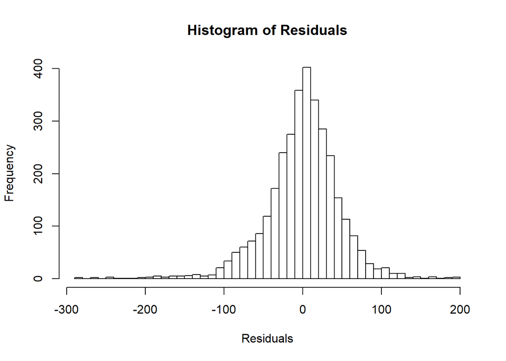

```r
hist(x=residuals(fit_fs), xlab = "Residuals", breaks = 50, main = "Histogram of Residuals")
```

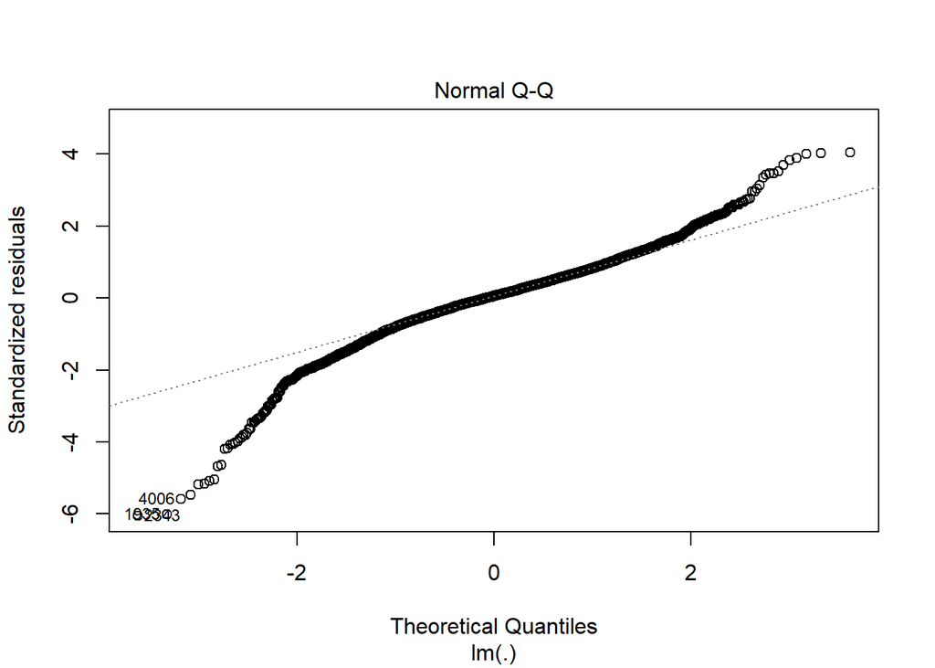

```r
plot(fit_fs, which = 2)
```

The histogram shows that the distribution of the residuals has the typical bell-shape of a normal distribution. The Q-Q plot shows that points beyond 2nd quantiles tend to drop further from normality. But by and large the points fall along the normal line.

### Constant Variability of Residuals

The Scale-Location plot provided by the R base `plot` function can be used to check if the variability of the residuals is nearly constant.

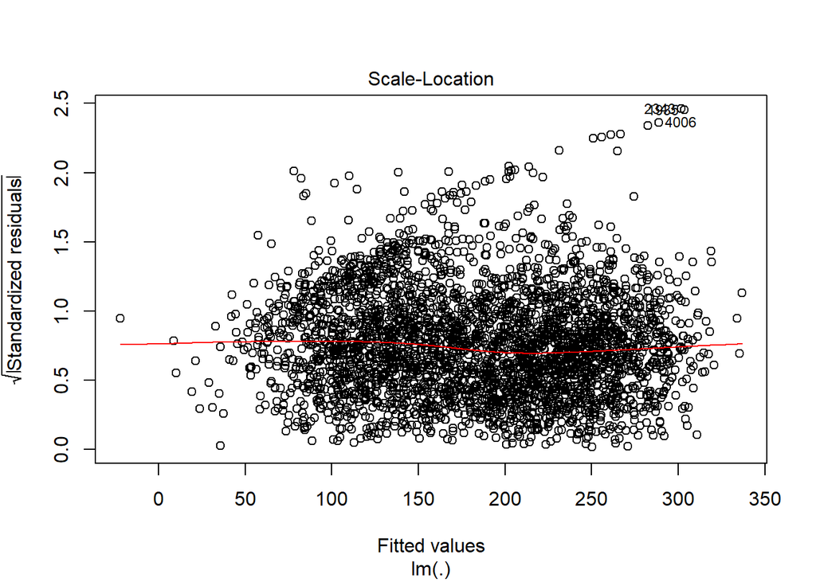

```r
plot(fit_fs, which = 3)
```

The red line through the center is nearly horizontal and flat, indicating that the variability is nearly constant. To be sure, the `ncvTest` function from the `car` package can be used to perform a hypothesis test. The null hypothesis is that the variance of the residuals is constant.

```r
ncvTest(fit_fs)
```

```
## Non-constant Variance Score Test
## Variance formula: ~ fitted.values
## Chisquare = 0.09496899    Df = 1     p = 0.7579527
```

The p-value is large, indicating that the null hypothesis cannot be rejected. There is no violation of the constant variability assumption.

### Residual Independence

The survey was done online. It is believed that there is no order on when each data point is collected. Therefore, the residuals are believed to be independent against the order of data collection.

Instead, we will check if there are relation between the residuals and some of the explanatory variables.

First, we sub-select from the `ds` table the cases that was actually used in the regression model. Recall that some of the cases were dropped due to explanatory variables having NA values in their answers, and the number of cases used is 3317.

```r
cases_used <- ds[names(fit_fs$fitted.values),]
dim(cases_used)
```

```
## [1] 3317  319
```

Place the residuals into the `cases_used` table.

```r
cases_used$residuals <- fit_fs$residuals
```

Below we attempt to plot the Residuals vs Variable for each explanatory variable in the model.

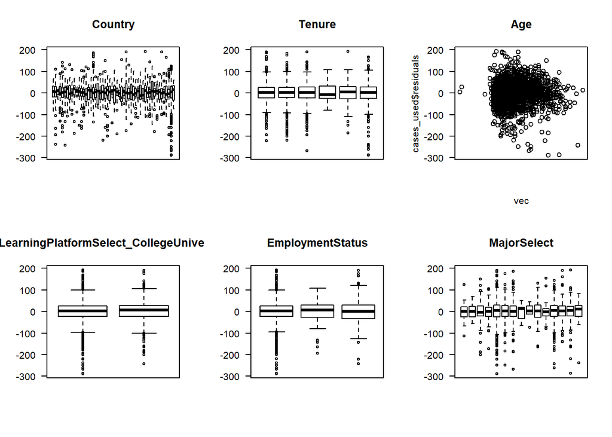

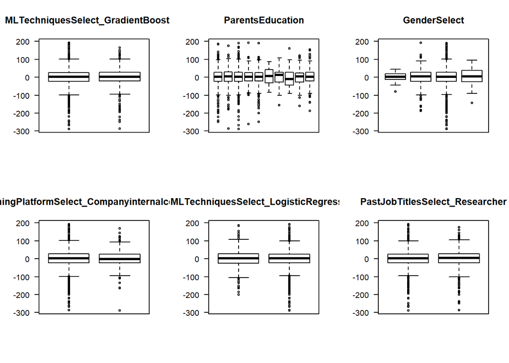

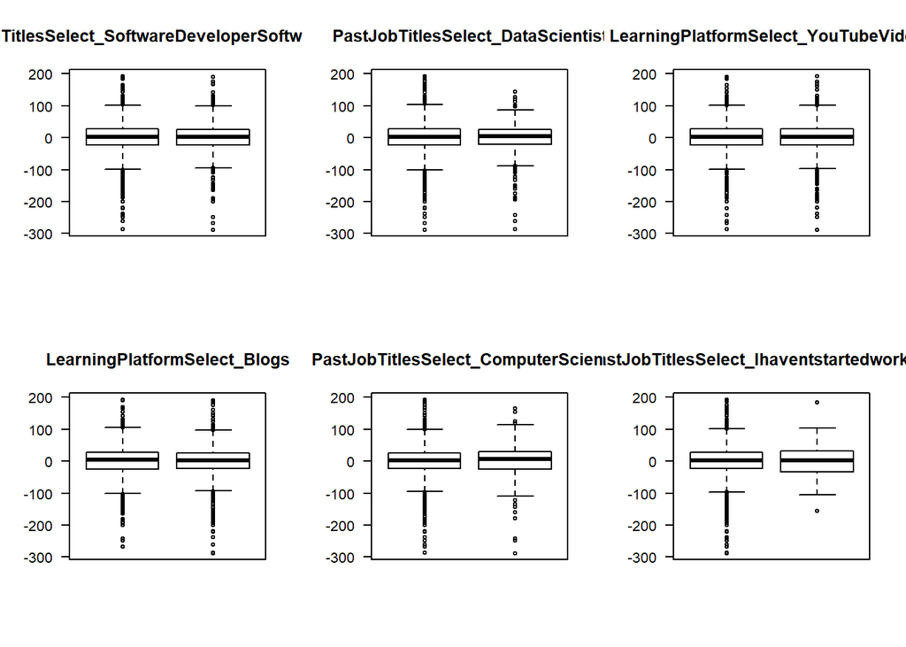

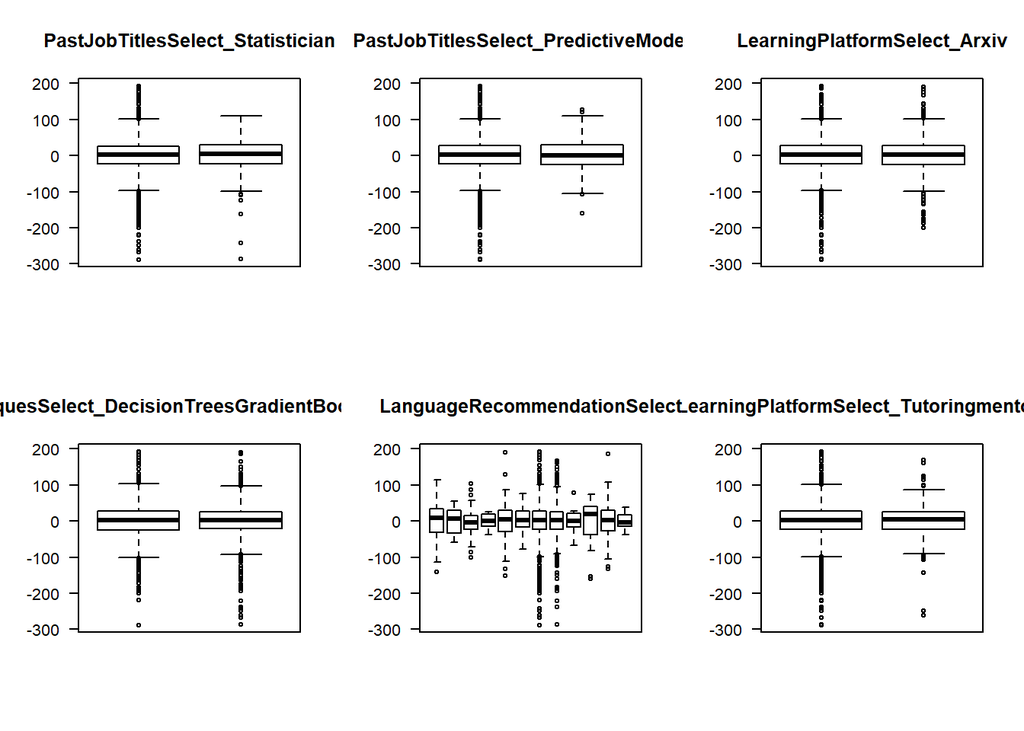

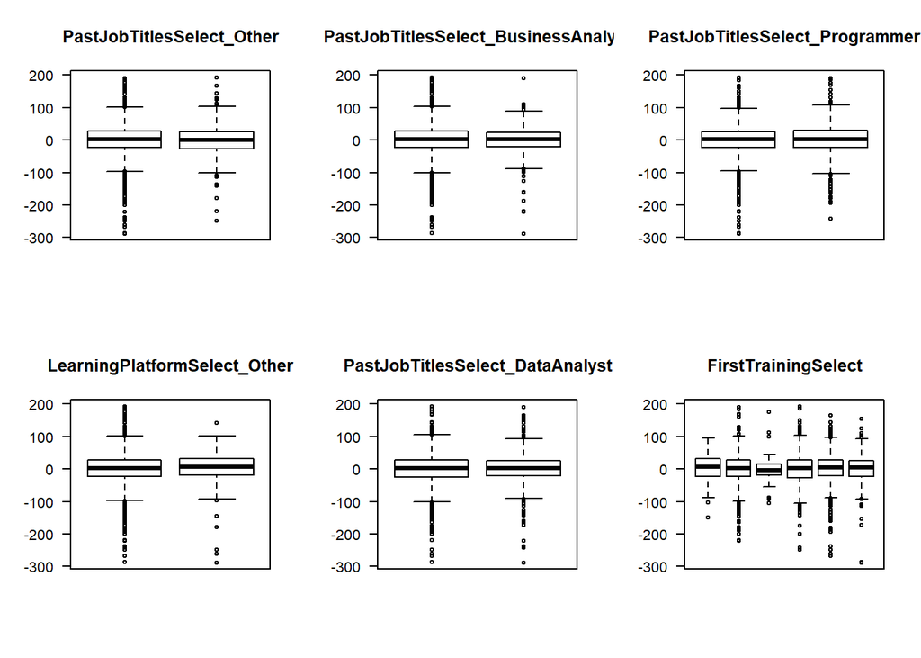

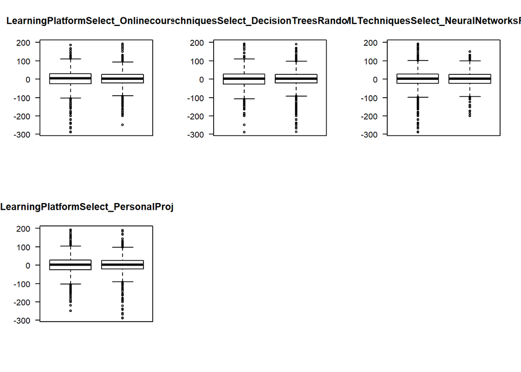

```r
par(mfrow=c(2,3))
for (var in var_add){
  colnum <- which(names(cases_used)==var)
  vec <- cases_used[,colnum]
  if (!is.numeric(vec)) {
    vec <- as.factor(vec)
  }
  plot(x = vec, y = cases_used$residuals, las=1, xaxt='n', main = var)
}
```

We observe that for some of the varibles, the residuals fluctuate across groups. The flucturation may be explained by the disparity of surveyees in the survey itself. For example, in the “GenderSelect” plot, it seems the “Male” group has a lot more variability than other groups. Examing the “GenderSelect” variable:

```r
temp <- cases_used %>%
  group_by(GenderSelect) %>%
  summarise(Group.Size = n())
kable(temp, "html") %>%
  kable_styling(bootstrap_options = "striped", full_width = F)
```

| GenderSelect | Group.Size |
| --- | --- |
| A different identity | 20 |
| Female | 438 |
| Male | 2842 |
| Non-binary, genderqueer, or gender non-conforming | 17 |

We see that the male group size is overwhelmingly larger than other groups in the “GenderSelect” variable. This maybe the reason causing the difference in variability.

### Linearity of Variables

In this check, we will see if the explanatory variables are reasonably related to the response variable. A table is constructed to include variables and the absolute value of correlation coefficient each variable has with the response variable (“Salary”).

```r
correlations <- c()
for (var in var_add){
  colnum <- which(names(cases_used)==var)
  vec <- cases_used[,colnum]
  if (!is.numeric(vec)) {
    vec <- as.numeric(as.factor(vec))
  }
  correlations <- c(correlations, cor(vec, cases_used$Salary))
}
temp <- data.frame(Variables = var_add, Correlations = abs(correlations))
kable(temp[order(temp$Correlations, decreasing=T), ], "html") %>%
  kable_styling(bootstrap_options = "striped", full_width = F)
```

|  | Variables | Correlations |
| --- | --- | --- |
| 3 | Age | 0.3907929 |
| 2 | Country | 0.3436060 |
| 9 | Tenure | 0.2855527 |
| 33 | MLTechniquesSelect_DecisionTreesRandomForests | 0.1582310 |
| 38 | MLTechniquesSelect_LogisticRegression | 0.1566681 |
| 58 | PastJobTitlesSelect_Other | 0.1374359 |
| 36 | MLTechniquesSelect_GradientBoosting | 0.1266431 |
| 32 | MLTechniquesSelect_DecisionTreesGradientBoostedMachines | 0.1223794 |
| 55 | PastJobTitlesSelect_Programmer | 0.1139259 |
| 49 | PastJobTitlesSelect_DataScientist | 0.1137154 |
| 14 | LearningPlatformSelect_CollegeUniversity | 0.1070584 |
| 60 | PastJobTitlesSelect_Ihaventstartedworkingyet | 0.1056898 |
| 29 | LearningPlatformSelect_YouTubeVideos | 0.0901854 |
| 15 | LearningPlatformSelect_Companyinternalcommunity | 0.0883143 |
| 23 | LearningPlatformSelect_PersonalProjects | 0.0871038 |
| 28 | LearningPlatformSelect_Tutoringmentoring | 0.0855499 |
| 8 | MajorSelect | 0.0837455 |
| 13 | LearningPlatformSelect_Blogs | 0.0728352 |
| 12 | LearningPlatformSelect_Arxiv | 0.0698747 |
| 54 | PastJobTitlesSelect_PredictiveModeler | 0.0685888 |
| 11 | ParentsEducation | 0.0537982 |
| 10 | FirstTrainingSelect | 0.0511451 |
| 46 | PastJobTitlesSelect_ComputerScientist | 0.0467508 |
| 1 | GenderSelect | 0.0410390 |
| 5 | LanguageRecommendationSelect | 0.0371732 |
| 4 | EmploymentStatus | 0.0369626 |
| 42 | MLTechniquesSelect_NeuralNetworksRNNs | 0.0369179 |
| 30 | LearningPlatformSelect_Other | 0.0337844 |
| 45 | PastJobTitlesSelect_BusinessAnalyst | 0.0329171 |
| 22 | LearningPlatformSelect_Onlinecourses | 0.0306097 |
| 56 | PastJobTitlesSelect_Researcher | 0.0161627 |
| 57 | PastJobTitlesSelect_SoftwareDeveloperSoftwareEngineer | 0.0136897 |
| 59 | PastJobTitlesSelect_Statistician | 0.0087566 |
| 47 | PastJobTitlesSelect_DataAnalyst | 0.0082300 |

The “Age”, “Country”, and “Tenure” variables are the top three in terms of correlation to “Salary”. At the bottom of the table are some of the “PasteJobTitlesSelect”. These contribute little to the model.

## Conclusion

A linear regression model is created to predict a data scientist’s salary, using data from Kaggle’s 2017 Data Scientist Survey. The response variable is the salary, transformed using Box Cox Transformation. Both backward elimination and forward selection are used to select the explanatory variables. The variables selected by the forward selection method are chosen due to the resulting model’s simplicity and higher F-statistics. The model has a adjusted R square of 0.6227859.

Model diagnostics are analyzed to check if any regression assumptions are violated. Below is a list of findings:

- The residuals are nearly normal, as shown in the histogram and Q-Q plot
- The variability of the residuals are nearly constant, as demonstrated by the Scale-Location plot and the Non-Constant Variance test
- Some of the variables exhibit fluctuation of residual distribution across their groups. This may be explained by the large disparity of surveyees across the groups.
- The absolute value of correlation coefficient is calculated for each explanatory variable with the response variable. The correlation ranges from 0.00823 to 0.3907929.

In retrospect, below is a list of weakness of this model that may need improvement.

- It may be better to eliminate some of the variables from the model. These are the variables having smaller correlation coefficient with the response variable, or having large p-value in the t-statistics calculated for the model.
- The residuals independence assumption may require a deeper look. If the residuals is dependent on the groups of a explanatory variable, this variable will need to be dropped from the model.

Lastly, below is a table listing all of the variables, weights, and statistics created by the linear regression.

```r
sumstats <- summary(fit_fs)
summary.table <- data.frame(sumstats$coefficient)
summary.table$variables <- row.names(summary.table)
row.names(summary.table) <- c(1:nrow(summary.table))
summary.table <- summary.table[,c(5,1,2,3,4)]
kable(summary.table, "html") %>%
  kable_styling(bootstrap_options = "striped", full_width = F)
```

| variables | Estimate | Std..Error | t.value | Pr…t.. |
| --- | --- | --- | --- | --- |
| (Intercept) | 79.4579763 | 20.4790925 | 3.8799559 | 0.0001066 |
| CountryAustralia | 74.5742548 | 12.1078541 | 6.1591637 | 0.0000000 |
| CountryBelarus | -15.6529326 | 30.1973723 | -0.5183541 | 0.6042472 |
| CountryBelgium | 46.1423219 | 14.2782433 | 3.2316526 | 0.0012433 |
| CountryBrazil | 2.6117022 | 11.6459699 | 0.2242580 | 0.8225709 |
| CountryCanada | 51.9348201 | 11.9151800 | 4.3587105 | 0.0000135 |
| CountryChile | 3.2767672 | 16.5488530 | 0.1980057 | 0.8430532 |
| CountryColombia | -9.4019223 | 13.4935921 | -0.6967694 | 0.4859979 |
| CountryCzech Republic | -6.1717452 | 15.3252463 | -0.4027175 | 0.6871830 |
| CountryDenmark | 47.2893708 | 15.2885110 | 3.0931312 | 0.0019977 |
| CountryEgypt | -76.8088702 | 18.9002971 | -4.0638975 | 0.0000494 |
| CountryFinland | 40.7568328 | 15.3396979 | 2.6569515 | 0.0079244 |
| CountryFrance | 40.7928579 | 11.6644572 | 3.4971930 | 0.0004766 |
| CountryGermany | 56.3626806 | 11.7738687 | 4.7870995 | 0.0000018 |
| CountryGreece | 20.8804234 | 15.1101980 | 1.3818762 | 0.1671065 |
| CountryHong Kong | 17.8438783 | 17.3119382 | 1.0307268 | 0.3027471 |
| CountryHungary | -37.7540467 | 16.1895853 | -2.3319959 | 0.0197628 |
| CountryIndia | -28.9767621 | 11.0840900 | -2.6142662 | 0.0089840 |
| CountryIndonesia | -53.4197823 | 15.3744645 | -3.4745784 | 0.0005185 |
| CountryIran | -28.8518063 | 16.6382591 | -1.7340640 | 0.0830033 |
| CountryIreland | 58.7699776 | 14.9598800 | 3.9285060 | 0.0000873 |
| CountryIsrael | 66.9679393 | 14.7169934 | 4.5503818 | 0.0000056 |
| CountryItaly | 26.8776770 | 12.4255366 | 2.1630999 | 0.0306075 |
| CountryJapan | 31.1665968 | 12.5266542 | 2.4880224 | 0.0128962 |
| CountryKenya | -59.2543072 | 17.7728755 | -3.3339741 | 0.0008659 |
| CountryMalaysia | -6.3609186 | 16.3334174 | -0.3894420 | 0.6969752 |
| CountryMexico | -18.6523691 | 13.1621194 | -1.4171250 | 0.1565440 |
| CountryNetherlands | 55.0980631 | 12.5167247 | 4.4019553 | 0.0000111 |
| CountryNew Zealand | 53.1472581 | 17.8195349 | 2.9825278 | 0.0028804 |
| CountryNigeria | -59.7147535 | 16.6874309 | -3.5784270 | 0.0003508 |

[output cut: 97 more lines]